Title: A protocal for data exploration Date: 2015-05-19 Tags: R, data exploration, outlier, normality Slug: data-exploration-protocal

## Step 1: Outliers

Outliers affect certain methos (e.g. linear regression). The authors recommend boxplots or Cleveland dotplots to detect outliers. I’ve written about visualizing outliers and distributions here. While boxplots are okay I prefer univariate dot-plots which are similar to Cleveland dotplots.

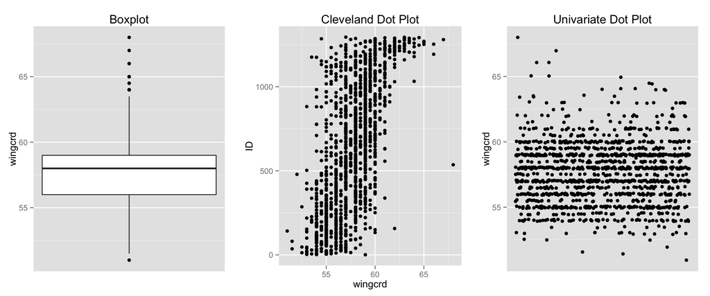

If you detect outliers, investigate to why they exist. Maybe measurement error. The authors recommending simulating repeated samples from the same distribution you assume your data is from, e.g. the normal distribution, and then comparing the simulated distributions to your data.

## Homogeneity of variance

Check if data have roughly the same variance for models where that is an assumption (like regression), either with distribution plots or residuals. Probably do both to verify.

## Normality of data

Are observations or residuals normally distributed? Check what the assumptions are. Plot histogram and/or Q-Q Plot. (more in anscombe blog post)

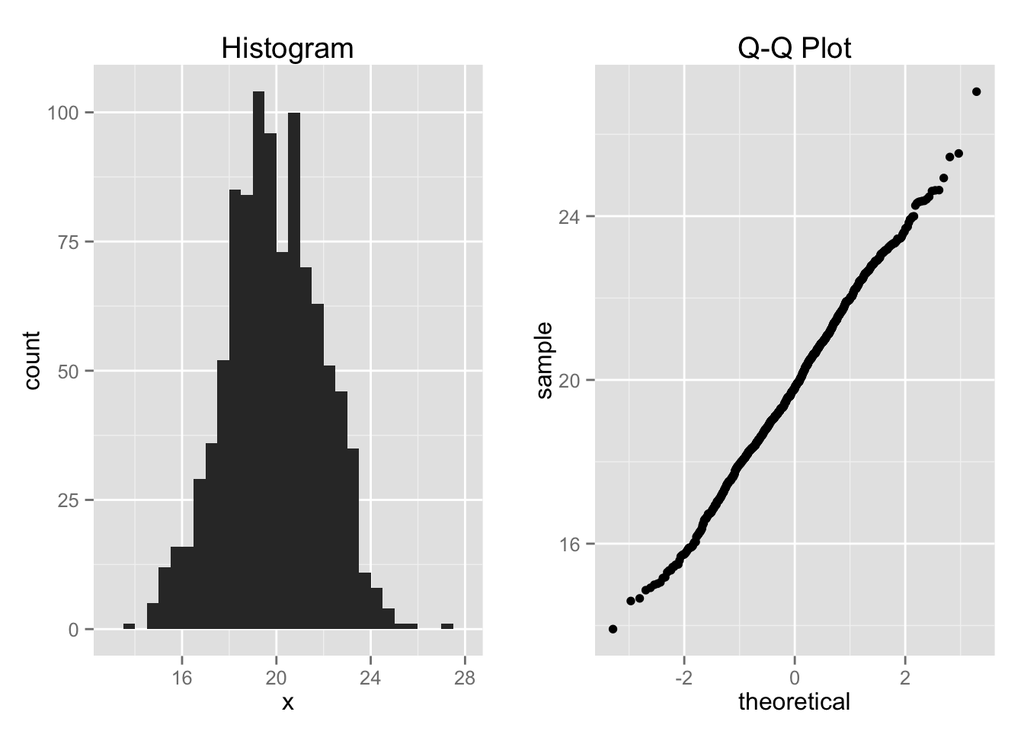